# HW2 - Do Households Value Transit-rich Neighborhoods compared to Others in Boston?

Jun, Youngsang

September 19, 2024

## Key Facts

1. In 2022, it has become more difficult to find a house for the same amount of money in Boston compared to 2012, despite the decrease in population per tract. This trend appears to be greater in TOD areas than in non-TOD areas.

## 1. Data Wrangling Work

The spatial analysis began with data wrangling by using Boston’s subway arc and node data, which includes 5 lines and 153 stations, provided by MBTA, along with ACS data from 2012 and 2022 for 438 tracts within Suffolk County, provided by the U.S. Census Bureau. The result of data wrangling work is as follows:

1. Load Libraries and Initial Setup

```r
# Install and Load Libraries
# install.packages('mapview')
library(tidyverse)
library(tidycensus)
library(sf)
library(kableExtra)
library(mapview)
library(dplyr)
library(viridis)

# Disable Scientific Notation
options(scipen=999)
options(tigris_class = "sf")

# Source for Multiple Ring Buffer
source("https://raw.githubusercontent.com/urbanSpatial/Public-Policy-Analytics-Landing/master/functions.r")

# Set Color Table
palette5 <- c("#f0f9e8","#bae4bc","#7bccc4","#43a2ca","#0868ac")

# Set ACS API Key
census_api_key("b2835f54d89a4499ba29829c908967b86765b345", overwrite = TRUE)
```

2. Wrangle ACS Data of Suffolk County (which Boston seats of) 2012 and 2022

```r
# Get ACS Data of Suffolk County 2012 and 2022
tracts12 <-
  get_acs(geography = "tract",
          variables = c("B01003_001E","B02001_002E",
                        "B15001_050E","B15001_009E",
                        "B19013_001E", "B25058_001E",
                        "B06012_002E"),
          year=2012, state="MA",
          county="Suffolk", geometry=TRUE) %>%
  st_transform('EPSG:26986') # Use NAD 83 CRS
tracts12 <- subset(tracts12, GEOID!='25025990101') # Error
tracts22 <-
  get_acs(geography = "tract",
          variables = c("B01003_001E","B02001_002E",
                        "B15001_050E","B15001_009E",
                        "B19013_001E", "B25058_001E",
                        "B06012_002E"), # Since B25026_001 is Total Population in
                                        # Occupied Housing Units, replaced it with B01003_001E
          year=2022, state="MA",
          county="Suffolk", geometry=TRUE) %>%
  st_transform('EPSG:26986') # Use NAD 83 CRS

# Transforming Long Data to Wide Data Using Spread
tracts12 <-
  tracts12 %>%
  dplyr::select( -NAME, -moe) %>%
  spread(key = variable, value = estimate) %>%
  rename(TotalPop = B01003_001,
         Whites = B02001_002,
         FemaleBachelors = B15001_050,
         MaleBachelors = B15001_009,
         MedHHInc = B19013_001,
         MedRent = B25058_001,
         TotalPoverty = B06012_002)

tracts22 <-
  tracts22 %>%
  dplyr::select( -NAME, -moe) %>%
  spread(key = variable, value = estimate) %>%
  rename(TotalPop = B01003_001,
         Whites = B02001_002,
         FemaleBachelors = B15001_050,
         MaleBachelors = B15001_009,
         MedHHInc = B19013_001,
         MedRent = B25058_001,
         TotalPoverty = B06012_002)

# Create Column that Calculates Proportion of Whites, Bachelors and Poverty
tracts12 <-
  tracts12 %>%
  mutate(pctWhite = ifelse(TotalPop > 0, Whites / TotalPop, 0),
         pctBachelors = ifelse(TotalPop > 0, ((FemaleBachelors + MaleBachelors) / TotalPop), 0),
         pctPoverty = ifelse(TotalPop > 0, TotalPoverty / TotalPop, 0),
         year = "2012") %>%
  dplyr::select(-Whites,-FemaleBachelors,-MaleBachelors,-TotalPoverty)

tracts22 <-
  tracts22 %>%
  mutate(pctWhite = ifelse(TotalPop > 0, Whites / TotalPop, 0),
         pctBachelors = ifelse(TotalPop > 0, ((FemaleBachelors + MaleBachelors) / TotalPop), 0),
         pctPoverty = ifelse(TotalPop > 0, TotalPoverty / TotalPop, 0),
         year = "2022") %>%
  dplyr::select(-Whites,-FemaleBachelors,-MaleBachelors,-TotalPoverty)

# Row Bind of 2012 and 2022
allTracts <- rbind(tracts12,tracts22)
```

3. Wrangling Boston’s Subway Arc and Node Data (MBTA Data)

```r
# Get MBTA Data of Transit Line and Node
MBTA_ARC <- st_read('./MBTA_RT/MBTA_ARC.shp')
MBTA_NODE <- st_read('./MBTA_RT/MBTA_NODE.shp')

# Create a Column in MBTA_NODE to Distinguish Transfer Stations
MBTA_NODE <- MBTA_NODE %>%
  mutate(transferstation = ifelse(LINE == "BLUE", "BLUE",ifelse(LINE == "ORANGE", "ORANGE",ifelse(LINE == "RED", "RED",ifelse(LINE == "SILVER", "SILVER", ifelse(LINE == "GREEN", "GREEN","TRANSFER"))))))
```

4. Check if the Locations of MBTA Data are precise in Online map (via Mapview)

```r
mapview(tracts22)+mapview(MBTA_ARC)+mapview(MBTA_NODE)
```

[interactive chart not shown]

5. Buffer Relating MBTA Data and Set TOD/Non-TOD area In this study, TOD area is defined as the total area of tracts whose centroids are located in 0.5 miles of each transit station. The following figure shows the buffer within 0.5 mile of each transit station. The color of line represents each service line, and black dots denote transfer stations.

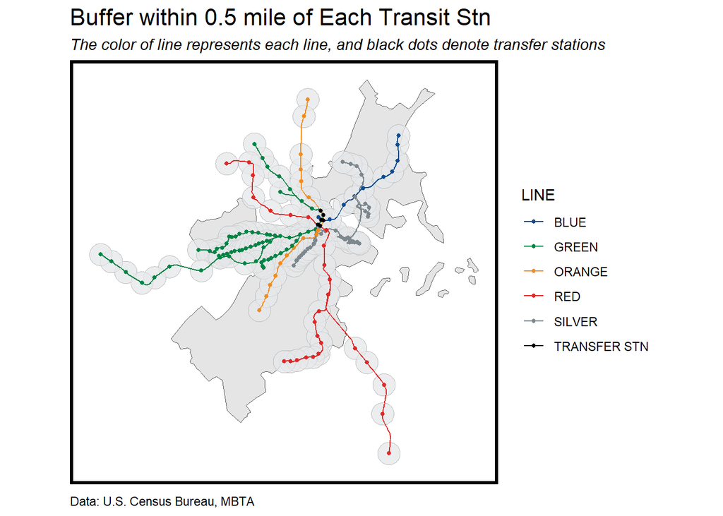

```r
stopBuffer <- st_buffer(MBTA_NODE, 805) # 805 meters which is equivalent to 0.5 miles
stopUnion <- st_union(st_buffer(MBTA_NODE, 805))
stopUnion <- st_make_valid(stopUnion)
MBTABuffers <-
  rbind(
     stopBuffer %>%
      mutate(Legend = "Buffer") %>%
      dplyr::select(Legend),
     stopUnion %>%
      st_sf() %>%
      mutate(Legend = "Unioned Buffer"))

ggplot() +
  geom_sf(data=st_union(tracts22)) +
  geom_sf(data=MBTABuffers, alpha=0.5, fill="#E5E7E9", color = "gray") +
  geom_sf(data=MBTA_ARC,
          aes(color = LINE),
          show.legend = "line", size= 2) +
  scale_color_manual(values = c("#0C4C91", "#008445", "#F18C20", "#E12726", "#7C878E")) +
  geom_sf(data=MBTA_NODE,
          aes(color = transferstation),
          show.legend = "point", size= 1)+
  scale_color_manual(values = c("#0C4C91", "#008445", "#F18C20", "#E12726", "#7C878E", "black"), labels = c("BLUE", "GREEN", "ORANGE", "RED", "SILVER", "TRANSFER STN")) +
  labs(title="Buffer within 0.5 mile of Each Transit Stn",
       subtitle="The color of line represents each line, and black dots denote transfer stations",
       caption="Data: U.S. Census Bureau, MBTA") +
  mapTheme()
```

6. Create Centroid

```r
buffer <- filter(MBTABuffers, Legend=="Unioned Buffer")

selectCentroids22 <-
  st_centroid(tracts22)[buffer,] %>%
  st_drop_geometry() %>%
  left_join(., dplyr::select(tracts22, GEOID), by = "GEOID") %>%
  st_sf() %>%
  dplyr::select(TotalPop) %>%
  mutate(year = "2022")
selectCentroids22_union <- st_union(selectCentroids22)%>%
  st_sf() %>%
  mutate(year = "2022")
selectCentroids12 <-
  st_centroid(tracts12)[buffer,] %>%
  st_drop_geometry() %>%
  left_join(., dplyr::select(tracts12, GEOID), by = "GEOID") %>%
  st_sf() %>%
  dplyr::select(TotalPop) %>%
  mutate(year = "2012")
selectCentroids12_union <- st_union(selectCentroids12)%>%
  st_sf() %>%
  mutate(year = "2012")
intersections1222_union <- rbind(selectCentroids22_union, selectCentroids12_union)

NODE22 <- st_intersection(MBTA_NODE, tracts22) %>%
  mutate(year = "2022")
NODE12 <- st_intersection(MBTA_NODE, tracts12) %>%
  mutate(year = "2012")
MBTA_NODE_CLIP <-
  rbind(NODE22,NODE12)
```

7. Row Bind for TOD, Non-TOD, by year

```r
allTracts.group <-
  rbind(
    st_centroid(allTracts)[buffer,] %>%
      st_drop_geometry() %>%
      left_join(allTracts) %>%
      st_sf() %>%
      mutate(TOD = "TOD"),
    st_centroid(allTracts)[buffer, op = st_disjoint] %>%
      st_drop_geometry() %>%
      left_join(allTracts) %>%
      st_sf() %>%
      mutate(TOD = "Non-TOD")) %>%
  mutate(MedRent.inf = ifelse(year == "2012", MedRent * 1.2747, MedRent)) %>% # Cumulative price change Inflation from 2012 to 2022 is  27.47%
  mutate(tractArea=st_area(geometry)) %>%
  mutate(tractpopDens=TotalPop*2589988/units::drop_units(tractArea))
```